# 131 HW6

```r
library(janitor)
```

```r
library(ggplot2)
library(dplyr)
library(tidyverse)
library(tidymodels)
library(corrplot)
library(rpart.plot)
library(ranger)
library(vip)
library(xgboost)
```

# Q1

```r
pokemon <- read.csv('data/pokemon.csv')
pokemon1 <- clean_names(pokemon)
pokemon_filtered <- pokemon1 %>%
  filter(type_1 == "Bug" | type_1 == "Fire" | type_1 == "Grass" | type_1 == "Normal" | type_1 == "Water" | type_1 == "Physic")

pokemon_filtered$type_1 <- as.factor(pokemon_filtered$type_1)
pokemon_filtered$legendary <- as.factor(pokemon_filtered$legendary)
pokemon_filtered$generation <- as.factor(pokemon_filtered$generation)

set.seed(3435)
pokemon_split <- initial_split(pokemon_filtered, prop = 0.7,
                               strata = type_1)
pokemon_testing <- testing(pokemon_split)
pokemon_training <- training(pokemon_split)

pokemon_fold <- vfold_cv(pokemon_training, v = 5, strata = type_1)

pokemon_training2 <- pokemon_training %>% dplyr :: select(type_1, legendary,
                                                          generation, sp_atk, attack, speed, defense, hp, sp_def)
pokemon_recipe <- recipe(type_1 ~ ., data = pokemon_training2) %>% step_dummy(legendary) %>%
  step_dummy(generation) %>% step_normalize(all_predictors())
```

# Q2

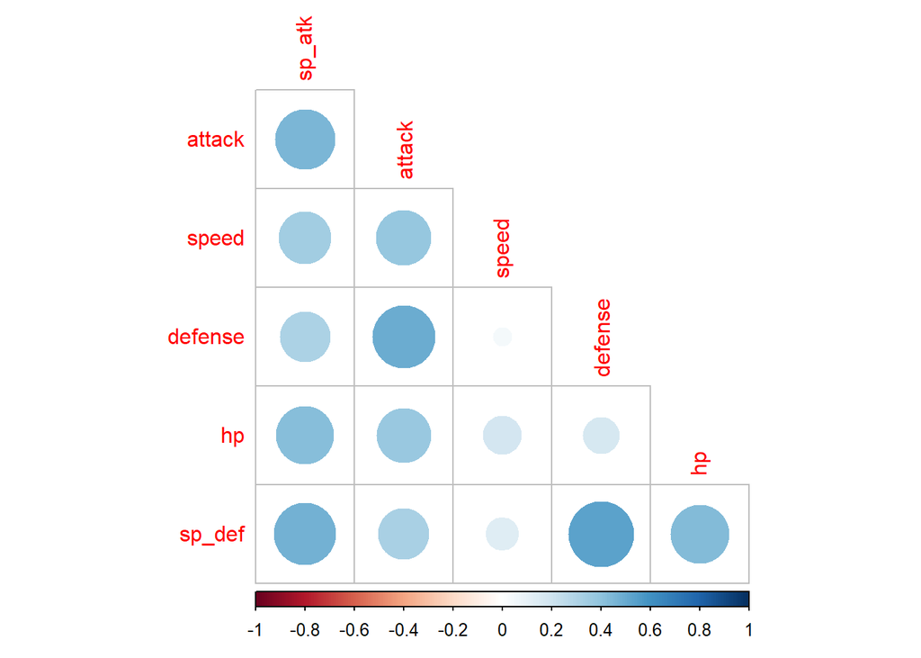

```r
pokemon_cor <- pokemon_training2 %>% select_if(is.numeric) %>%
  cor() %>% corrplot(type = "lower", diag = FALSE)
```

I chose only the numerical variables for the correlation matrix since these numeric variables are the combat stat of the pokemons which I thought was worth looking at.

From the correlation matrix, we can see that defense has a relatively strong correlation with sp_def which make sense to me since sp_def is the resistance to special attacks while defense is the resistance to attacks.

# Q3

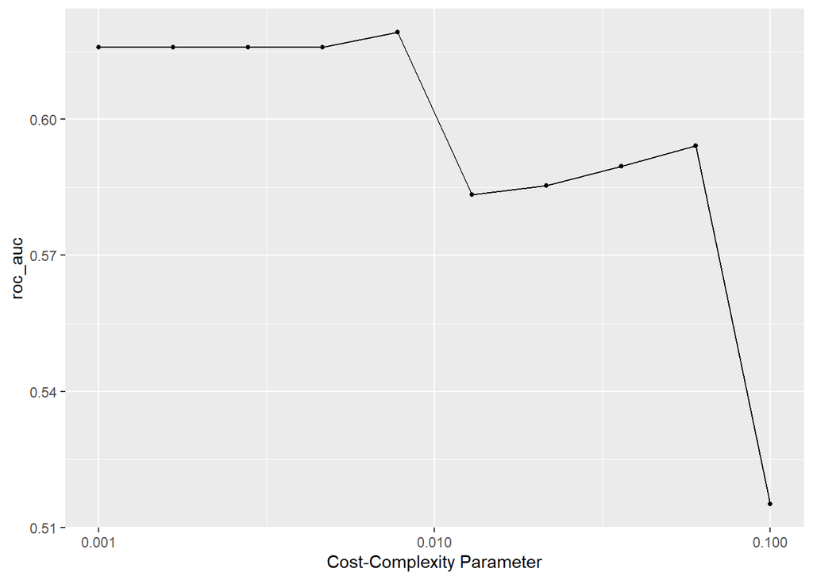

```r
tree_spec <- decision_tree() %>% set_engine("rpart") %>% set_mode("classification")
tree_wf <- workflow() %>%
  add_model(tree_spec %>% set_args(cost_complexity = tune())) %>%
  add_recipe(pokemon_recipe)

pokemon_grid <- grid_regular(cost_complexity(range = c(-3, -1)), levels = 10)
tune <- tune_grid(tree_wf, resamples = pokemon_fold,
  grid = pokemon_grid, metrics = metric_set(roc_auc))
autoplot(tune)
```

From the plot, we can see that roc_auc increases gradually with Cost-Complexity at first, when it reaches the peak value, it started to decrease drastically. In conclusion, picking a medium value for complexity penalty would result in the best performing tree.

# Q4

```r
collect_metrics(tune) %>% arrange(mean)
```

```
## # A tibble: 10 x 7
##    cost_complexity .metric .estimator  mean     n std_err .config
##              <dbl> <chr>   <chr>      <dbl> <int>   <dbl> <chr>
##  1         0.1     roc_auc hand_till  0.515     5  0.0204 Preprocessor1_Model10
##  2         0.0129  roc_auc hand_till  0.583     5  0.0247 Preprocessor1_Model06
##  3         0.0215  roc_auc hand_till  0.585     5  0.0287 Preprocessor1_Model07
##  4         0.0359  roc_auc hand_till  0.590     5  0.0322 Preprocessor1_Model08
##  5         0.0599  roc_auc hand_till  0.594     5  0.0302 Preprocessor1_Model09
##  6         0.001   roc_auc hand_till  0.616     5  0.0328 Preprocessor1_Model01
##  7         0.00167 roc_auc hand_till  0.616     5  0.0328 Preprocessor1_Model02
##  8         0.00278 roc_auc hand_till  0.616     5  0.0328 Preprocessor1_Model03
##  9         0.00464 roc_auc hand_till  0.616     5  0.0328 Preprocessor1_Model04
## 10         0.00774 roc_auc hand_till  0.619     5  0.0329 Preprocessor1_Model05
```

```r
best_complexity <- select_best(tune, metric = "roc_auc")
best_complexity
```

```
## # A tibble: 1 x 2
##   cost_complexity .config
##             <dbl> <chr>
## 1         0.00774 Preprocessor1_Model05
```

The roc_auc of the best performing model is 0.6191840, with cost_complexity 0.007742637

# Q5

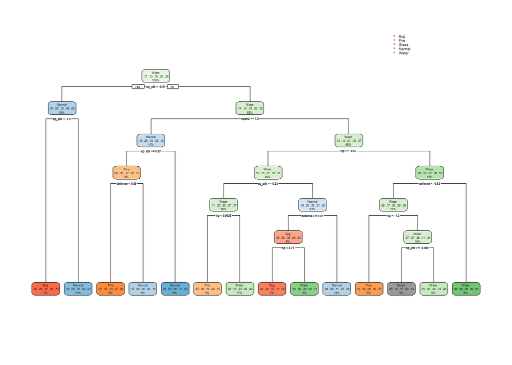

```r
final_tree <- finalize_workflow(tree_wf, best_complexity)
final_fit <- fit(final_tree, data = pokemon_training)
final_fit %>% extract_fit_engine() %>% rpart.plot(roundint = FALSE)
```

```r
forest_spec <- rand_forest() %>% set_engine("ranger", importance = "impurity") %>%
  set_mode("classification")

forest_wf <- workflow() %>%
  add_model(forest_spec %>%
  set_args(mtry = tune(), trees = tune(), min_n = tune())) %>%
  add_recipe(pokemon_recipe)
```

mtry: The number of predictors that will be randomly sampled with each split. trees: The number of trees. min_n: Minimum number of points to make a split.

```r
pokemon_grid2 <- grid_regular(mtry(range = c(1,8)), trees(range(1,200)), min_n(range(1,20)), levels = 8)
multi_tune <- tune_grid(
  forest_wf, resamples = pokemon_fold, grid = pokemon_grid2, metrics = metric_set(roc_auc))
```

# Q6

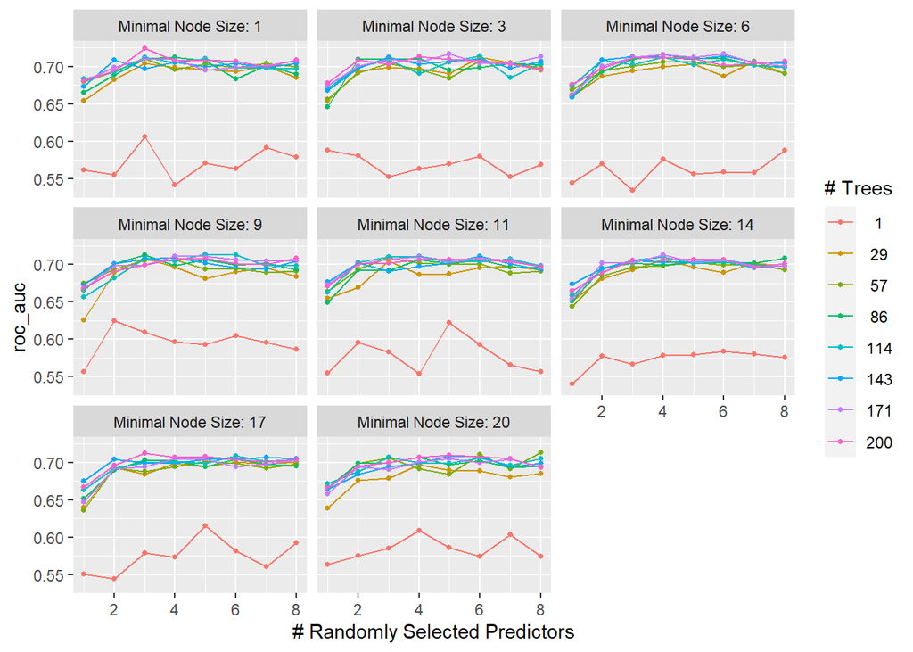

```r
autoplot(multi_tune)
```

From the plots, we can see that 1 tree has low roc_auc while 200 trees has the highest roc_auc in general. mtry seems to have a random effect on roc_auc. min_n does not seem to have huge effect on model performance.

# Q7

```r
collect_metrics(multi_tune) %>% arrange(mean)
```

```
## # A tibble: 512 x 9
##     mtry trees min_n .metric .estimator  mean     n std_err .config
##    <int> <int> <int> <chr>   <chr>      <dbl> <int>   <dbl> <chr>
##  1     3     1     6 roc_auc hand_till  0.534     5  0.0211 Preprocessor1_Model~
##  2     1     1    14 roc_auc hand_till  0.540     5  0.0364 Preprocessor1_Model~
##  3     4     1     1 roc_auc hand_till  0.541     5  0.0250 Preprocessor1_Model~
##  4     2     1    17 roc_auc hand_till  0.544     5  0.0268 Preprocessor1_Model~
##  5     1     1     6 roc_auc hand_till  0.545     5  0.0134 Preprocessor1_Model~
##  6     1     1    17 roc_auc hand_till  0.551     5  0.0297 Preprocessor1_Model~
##  7     7     1     3 roc_auc hand_till  0.552     5  0.0127 Preprocessor1_Model~
##  8     3     1     3 roc_auc hand_till  0.553     5  0.0263 Preprocessor1_Model~
##  9     4     1    11 roc_auc hand_till  0.554     5  0.0258 Preprocessor1_Model~
## 10     1     1    11 roc_auc hand_till  0.554     5  0.0127 Preprocessor1_Model~
## # ... with 502 more rows
```

```r
best_model <- select_best(multi_tune, metric = "roc_auc")
best_model
```

```
## # A tibble: 1 x 4
##    mtry trees min_n .config
##   <int> <int> <int> <chr>
## 1     3   200     1 Preprocessor1_Model059
```

# Q8

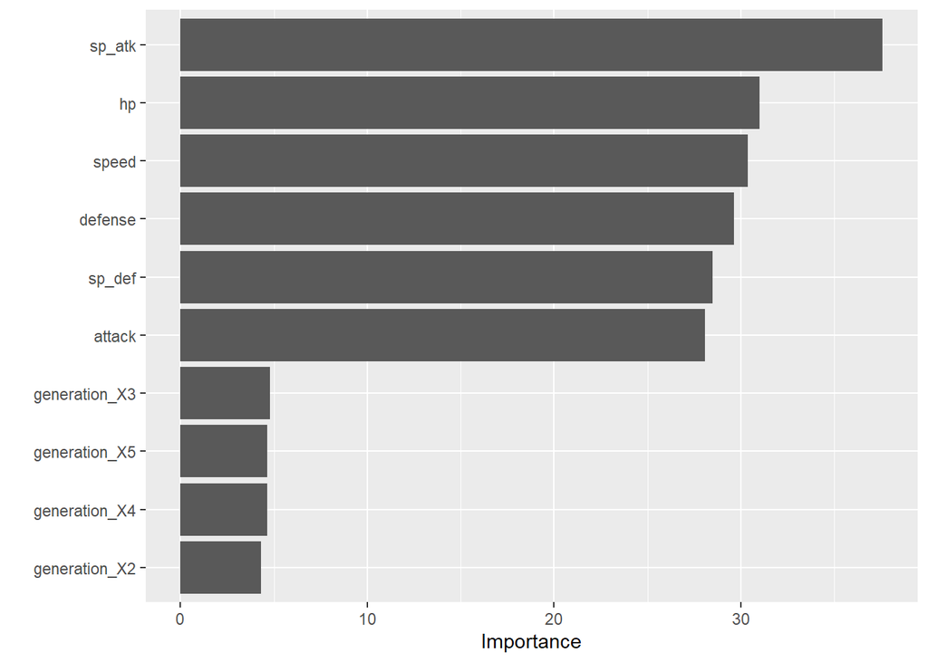

```r
final_best_model <- finalize_workflow(forest_wf, best_model)
final_best_fit <- fit(final_best_model, data = pokemon_training)
final_best_fit %>% extract_fit_engine() %>% vip()
```

# Q9

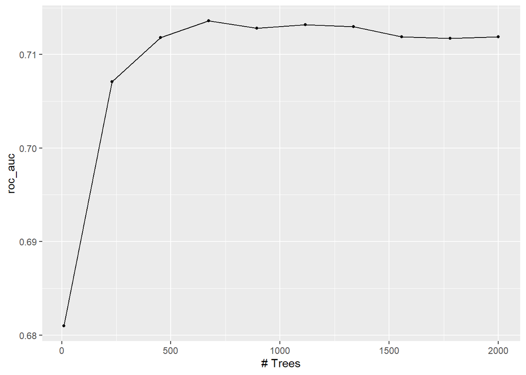

```r
boost_spec <- boost_tree() %>% set_engine("xgboost") %>% set_mode("classification")
boost_wf <- workflow() %>%
  add_model(boost_spec %>% set_args(trees = tune())) %>%
  add_recipe(pokemon_recipe)

boost_grid <- grid_regular(trees(range = c(10,2000)), levels = 10)

boost_tune <- tune_grid(boost_wf, resamples = pokemon_fold,
  grid = boost_grid, metrics = metric_set(roc_auc))
autoplot(boost_tune)
```

```r
collect_metrics(boost_tune) %>% arrange(mean)
```

```
## # A tibble: 10 x 7
##    trees .metric .estimator  mean     n std_err .config
##    <int> <chr>   <chr>      <dbl> <int>   <dbl> <chr>
##  1    10 roc_auc hand_till  0.681     5  0.0343 Preprocessor1_Model01
##  2   231 roc_auc hand_till  0.707     5  0.0237 Preprocessor1_Model02
##  3  1778 roc_auc hand_till  0.712     5  0.0248 Preprocessor1_Model09
##  4   452 roc_auc hand_till  0.712     5  0.0244 Preprocessor1_Model03
##  5  2000 roc_auc hand_till  0.712     5  0.0246 Preprocessor1_Model10
##  6  1557 roc_auc hand_till  0.712     5  0.0247 Preprocessor1_Model08
##  7   894 roc_auc hand_till  0.713     5  0.0242 Preprocessor1_Model05
##  8  1336 roc_auc hand_till  0.713     5  0.0246 Preprocessor1_Model07
##  9  1115 roc_auc hand_till  0.713     5  0.0247 Preprocessor1_Model06
## 10   673 roc_auc hand_till  0.714     5  0.0245 Preprocessor1_Model04
```

```r
best_boost_model <- select_best(boost_tune, metric = "roc_auc")
best_boost_model
```

```
## # A tibble: 1 x 2
##   trees .config
##   <int> <chr>
## 1   673 Preprocessor1_Model04
```

The roc_auc of my best_performing model is 0.7135988.

# Q10

```r
pruned_roc_auc <- collect_metrics(tune) %>% arrange(-mean)
forest_roc_auc <- collect_metrics(multi_tune) %>% arrange(-mean)
boost_roc_auc <- collect_metrics(boost_tune) %>% arrange(-mean)
roc_auc <- c(pruned_roc_auc$mean[1], forest_roc_auc$mean[1], boost_roc_auc$mean[1])
roc_auc
```

```
## [1] 0.6191840 0.7245466 0.7135988
```

The random forest model performed the best while pruned tree performed the worst.

```r
best_forest <- select_best(multi_tune)
best_forest_model <- finalize_workflow(forest_wf, best_forest)
best_forest_fit <- fit(best_forest_model, data = pokemon_testing)

prediction <- augment(best_forest_fit, new_data = pokemon_testing) %>%
  select(type_1,
         .pred_class,
         .pred_Bug,
         .pred_Fire,
         .pred_Grass,
         .pred_Normal,
         .pred_Water)

accuracy(prediction, type_1, .pred_class)
```

```
## # A tibble: 1 x 3
##   .metric  .estimator .estimate
##   <chr>    <chr>          <dbl>
## 1 accuracy multiclass     0.984
```

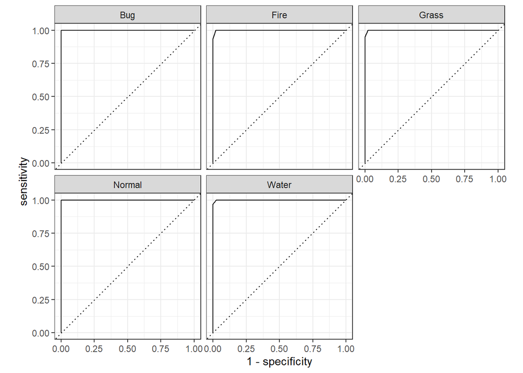

```r
prediction %>%
  roc_curve(type_1,.pred_Bug,
                   .pred_Fire,
                   .pred_Grass,
                   .pred_Normal,
                   .pred_Water) %>%
  autoplot()
```

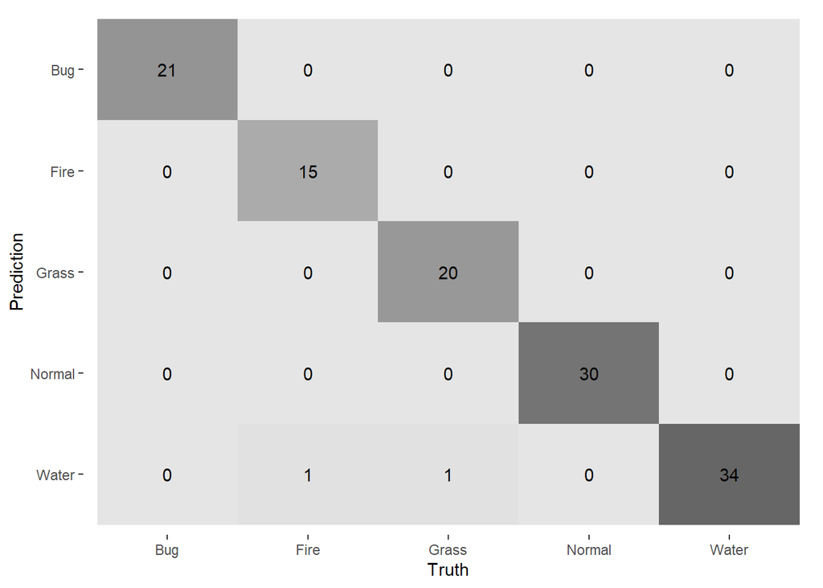

```r
prediction %>%
  conf_mat(type_1, .pred_class) %>%
  autoplot(type = "heatmap")
```

My model was performing best on predicting Bug type pokemon while performing worst on predicting fire type pokemon.